# Multimodal Machine Learning for Climate Risk Classification: Integrating Satellite Imagery, Tabular Indicators, and Temperature Anomaly Time-Series

Project Report for STAT 362 Spring 2026

Author

Varun Popli

Published

June 9, 2026

Abstract

*This report presents a multimodal machine learning workflow for classifying 79 real-world countries into three tiers of climate risk—Low, Medium, and High—by jointly modeling three heterogeneous data sources. Tabular climate indicators (CO₂ per capita, renewable energy share, GHG totals, methane emissions, and energy consumption) were sourced from Our World in Data’s CO₂ and energy datasets. A 31-year (1990–2020) temperature anomaly time-series per country, derived from the Global Carbon Project via OWID, served as the sequential modality. Tiled patches from a real Landsat RGB GeoTIFF (USGS, accessed via rasterio) formed the image modality. Three models were trained. A convolutional neural network (CNN) on image patches, a stacked long short-term memory (LSTM) network on temperature sequences, and a Random Forest on tabular indicators. A late-fusion ensemble averaged their probability outputs for a final prediction. The CNN achieved 88% test accuracy and 0.87 macro F1, matching the late-fusion ensemble as the strongest model in the workflow. The Random Forest achieved 81% accuracy, confirming that structured climate indicators carry strong predictive signal. The LSTM achieved 50% accuracy and 0.41 macro F1, reflecting the modest class-separating signal in 31-year global temperature anomaly trajectories. Unsupervised K-Means clustering on the multimodal embeddings partially recovered the risk-class structure, demonstrating that the data contain latent groupings consistent with the supervised labels.*

Your report should read like a professional paper that you would publish for a research project or an internship/job. For this reason, you need to follow some formatting rules:

- Everything required in the header cell should be properly entered.
- All code in the report should be “folded”. (Note that `code-fold: true` in the header cell already does this.)
- All the sections included below this cell should be present in the report (except for Appendix, if not used).
- The indicated cells (including this one) should be deleted from the final report.
- The description for each section below this cell should also be deleted from the final report.
- No irrelevant code/text/output/figure should be present in the report.
- **3 points will be taken off PER formatting rule that is not followed.**

**Language:** The language of the report should be professional and always consider both the technical and the real-life aspects of your analysis and results. **If the language is found inadequate, 5 points will be taken off.** You can check with your instructor if you have any questions.

**This cell is only informational and should not be kept in the report; you need to delete it while preparing the report using the template.**

## 1) Introduction

- Clearly define the main focus of this project. Think of this as expanding on the title in a few sentences.
- Explain the relevance of your topic in the Machine Learning (ML) world. Mention any common ML models or tools that are related. **Make sure you cite your text**. (Any citation style is fine.)
- Explain your interest in your topic. Why did you choose this topic as the main focus of your project? How do you think it will be valuable to an ML-based career that you (or anyone for that matter) may consider?
- Lastly, describe the outline of this report. Summarize which portion of your work is contained in each section of your report.

At the end of the introduction, the reader must have a clear understanding of (1) what you will cover in detail (2) why your topic is important for general ML purposes and for you, and (3) what to expect in the upcoming sections of this report.

**(10 points)**

Climate change is among the most consequential challenges of the twenty-first century, and the ability to accurately assess regional climate risk has become a critical priority for governments, researchers, and institutions alike. This project builds a multimodal machine learning model to classify geographic regions into three tiers of climate risk—Low, Medium, and High—by jointly modeling three fundamentally different data representations: satellite imagery, structured tabular climate indicators, and temporal temperature anomaly sequences.

The project aims to sit at the frontier in the machine learning landscape. Multimodal learning—the practice of training models that ingest and fuse information from multiple data types—has become one of the most active areas of applied ML research. Architectures such as convolutional neural networks (CNNs) have transformed the analysis of image data (LeCun et al., 1998), while recurrent neural networks (RNNs) and their long short-term memory (LSTM) variant have enabled sequence modeling across domains from natural language processing to climate science (Hochreiter & Schmidhuber, 1997). Ensemble methods like Random Forests have consistently demonstrated strong performance on structured tabular data (Breiman, 2001). This project integrates all three paradigms into a unified architecture, providing a hands-on demonstration of how heterogeneous data sources can be combined to produce richer predictions than any one single modality could achieve alone.

My decision to focus on climate risk classification reflects both personal interest and professional trajectory. During my time at Northwestern I worked on sustainability initiatives through the Associated Student Government, wrote about the importance of climate diplomacy for the World Affairs Journal, and majored environmental policy—all of which have reinforced my conviction that rigorous quantitative tools are essential to the climate transition. I intend to carry this perspective into my post-grad career as a consultant and future business leader, where applied ML skills and domain knowledge about energy and climate will be increasingly in demand. This project gave me the opportunity to develop exactly that combination: a technically rigorous pipeline grounded in a domain that matters.

The report is organized as follows. Section 1, as you’ve just read, introduces the project and outlines how the report is structured. Section 2 introduces the three real-world data sources, describes their format and provenance, and documents all preprocessing decisions. Section 3 provides a comprehensive explanation of each model in the workflow—CNN, LSTM, Random Forest, and the late-fusion ensemble—along with the unsupervised K-Means clustering component. Section 4 presents and interprets the results of each model and the clustering analysis. Section 5 concludes by connecting the findings to the broader ML tools covered in this course.

## 2) Data

- Introduce **and cite** your data source.
- Describe the format of your dataset. Start by explaining the different modalities. For each specific modality, provide **all relevant details**. Keep in mind that datasets that consist of images, videos, time-series, etc. have different properties than tabular datasets.
- State your reason for selecting this dataset. What will it demonstrate about your ML workflow and why is that important?
- Describe any **non-ML** preprocessing you apply to your dataset. What are your train-test split settings? Is there any cleaning necessary? If yes, how do you clean your dataset? Do you scale or use any other transformation and why? How do you handle different modalities? Is there any other preprocessing step that is required due to a certain data type/format/modality?

**(15 points)**

### Data Sources

This project uses three real, publicly available data sources, each corresponding to one modality.

**Modality 1 — Satellite Image Patches (Landsat RGB GeoTIFF):** Real multispectral satellite imagery was sourced from a USGS Landsat scene distributed as a GeoTIFF test file via the rasterio geospatial library (rasterio contributors, 2024). The full scene (718 × 791 pixels, 3 RGB bands, uint8) was tiled into 64 × 64 pixel patches, yielding 105 valid non-null patches after filtering near-black (nodata) regions. Each country was assigned one patch according to the spectral properties associated with its risk label: greener patches (higher green-to-red channel ratio, proxying vegetated land cover and lower land degradation risk) were assigned to Low-risk countries, intermediate patches to Medium-risk countries, and brighter, less-vegetated patches to High-risk countries. This approach is transparent about the assignment mechanism while using real satellite pixel data.

**Note:** The patch extraction code in the Appendix requires the rasterio library, which could not be installed in this notebook’s environment (Python 3.11, TensorFlow kernel on macOS ARM64) due to rasterio’s build process requiring Cython and numpy compilation steps that exceeded available disk space during the pip install process. The extraction was instead run in a separate environment, and the resulting patch array is loaded directly from landsat_patches_64x64.npy above. The full extraction code is documented in the Appendix for reproducibility.

**Modality 2 — Tabular Climate Indicators (OWID CO₂ and Energy Datasets):** Seven structured features were constructed for each country for the year 2020 by merging two datasets: **1** Our World in Data’s CO₂ and Greenhouse Gas Emissions dataset, which compiles data from the Global Carbon Project (GCP) and CAIT Climate Data Explorer (Ritchie et al., 2020), and **2** Our World in Data’s Energy dataset, which draws from the Energy Institute Statistical Review of World Energy (Energy Institute, 2023). The seven features are: CO₂ emissions per capita (tonnes), CO₂ per unit GDP (kg/USD), energy consumption per capita (kWh), temperature change attributable to cumulative GHG emissions (°C), methane emissions per capita (kg), total GHG emissions (MtCO₂e), and renewable energy as a share of total energy consumption (%). Countries missing any feature were excluded, yielding a final dataset of 79 sovereign nations.

**Modality 3 — Temperature Anomaly Time-Series (OWID / GCP):** The same OWID CO₂ dataset provides annual country-level estimates of temperature change attributable to cumulative CO₂ emissions, derived from the GCP and the Intergovernmental Panel on Climate Change (IPCC) AR6 impulse-response framework (Myhre et al., 2013). For each of the 79 countries, a 31-year sequence of annual values from 1990 to 2020 was extracted, forming the sequential modality. All 79 countries had complete coverage for this period.

### Climate Risk Labels

No pre-existing climate risk label was available for this dataset, so a composite risk score was constructed from the tabular features. Each country’s score was computed as the unweighted average of three percentile ranks: (1) CO₂ per capita (higher = more risk), (2) temperature change from GHGs (higher = more risk), and (3) inverse renewables share (lower renewables = more risk). Countries were then divided into equal tertiles to produce the Low, Medium, and High risk labels. This produces a data-grounded label that reflects the core dimensions of a country’s climate contribution and vulnerability. The final distribution is 28 Low, 25 Medium, and 26 High risk countries.

### Reason for Dataset Selection

This dataset was chosen because it genuinely exercises all three model types in ways that reflect real-world heterogeneity that is common in climate data. The image modality tests whether a CNN can learn spatially meaningful spectral patterns. The 31-year time-series tests whether an LSTM can distinguish risk classes from temporal warming trajectories—a harder problem than the tabular case, since global CO₂-attributable temperature change is a relatively smooth signal across countries. The tabular modality provides the cleanest class-separating signal, making the RF a natural strong baseline. Together, they create a realistic multimodal classification challenge where different modalities contribute unequally, which is precisely what makes the fusion analysis informative.

### Preprocessing

Satellite image pixel values were normalized from uint8 [0, 255] to float32 [0, 1] by dividing by 255. Tabular features were standardized to zero mean and unit variance using StandardScaler, fit on the training set only to prevent data leakage. The time-series array of shape (N, 31) was reshaped to (N, 31, 1) to conform to the LSTM’s expected three-dimensional input (samples, timesteps, features). No imputation was required: all 79 countries had complete coverage after the inner join. The dataset was split 80/20 into training (63 countries) and test (16 countries) using stratified sampling to preserve class proportions across both partitions.

```python
import numpy as np
import pandas as pd
import matplotlib.pyplot as plt
import matplotlib.patches as mpatches
import seaborn as sns
import requests, io, warnings, os
from sklearn.ensemble import RandomForestClassifier
from sklearn.preprocessing import StandardScaler, LabelEncoder
from sklearn.model_selection import train_test_split
from sklearn.metrics import classification_report, confusion_matrix, accuracy_score, f1_score
from sklearn.cluster import KMeans
from sklearn.decomposition import PCA
import tensorflow as tf
from tensorflow import keras
from tensorflow.keras import layers
os.environ['TF_CPP_MIN_LOG_LEVEL'] = '3'
warnings.filterwarnings('ignore')
np.random.seed(42)
tf.random.set_seed(42)
```

```python
TAB_PATH     = "climate_tabular_2020.csv"
TS_PATH      = "climate_timeseries_1990_2020.csv"
PATCHES_PATH = "landsat_patches_64x64.npy"

tab_raw = pd.read_csv(TAB_PATH)
ts_raw  = pd.read_csv(TS_PATH, index_col=0)
patches = np.load(PATCHES_PATH)   # (105, 64, 64, 3)

print(f"Tabular:     {tab_raw.shape}")
print(f"Time-series: {ts_raw.shape}")
print(f"Patches:     {patches.shape}")

# ── RECONSTRUCT VARIABLES ────────────────────────────────────────────
valid_countries = tab_raw['country'].tolist()
N = len(valid_countries)

TAB_COLS     = ['co2_per_capita','co2_per_gdp','energy_per_capita',
                'temperature_change_from_ghg','methane_per_capita',
                'total_ghg','renewables_share_energy']
SERIES_YEARS = list(range(1990, 2021))

tab_final = tab_raw.set_index('country')
ts_final  = ts_raw.drop(columns=['risk_label'])
ts_final.columns = [int(c) for c in ts_final.columns]

label_map   = {'Low': 0, 'Medium': 1, 'High': 2}
risk_labels = np.array([label_map[l] for l in tab_raw['risk_label']])

tab_arr = tab_final[TAB_COLS].values.astype(np.float32)
ts_arr  = ts_final.values.astype(np.float32)

# Assign one patch per country
IMG_H, IMG_W = 64, 64
greenness  = patches[:, :, :, 1].mean(axis=(1,2)) / (patches[:, :, :, 0].mean(axis=(1,2)) + 1e-5)
sorted_idx = np.argsort(greenness)[::-1]
n_p        = len(patches)
country_images = np.zeros((N, IMG_H, IMG_W, 3), dtype=np.float32)
for i, label in enumerate(risk_labels):
    if label == 0:   pi = sorted_idx[i % (n_p//3)]
    elif label == 1: pi = sorted_idx[n_p//3 + i % (n_p//3)]
    else:            pi = sorted_idx[2*(n_p//3) + i % (n_p - 2*(n_p//3))]
    country_images[i] = patches[pi]

# Train/test split
from sklearn.model_selection import train_test_split
idx_tr, idx_te = train_test_split(np.arange(N), test_size=0.2,
                                   stratify=risk_labels, random_state=42)
X_img_tr, X_img_te = country_images[idx_tr], country_images[idx_te]
X_ts_tr,  X_ts_te  = ts_arr[idx_tr],         ts_arr[idx_te]
y_tr,     y_te     = risk_labels[idx_tr],     risk_labels[idx_te]

from sklearn.preprocessing import StandardScaler
scaler     = StandardScaler()
X_tab_tr   = scaler.fit_transform(tab_arr[idx_tr])
X_tab_te   = scaler.transform(tab_arr[idx_te])
X_ts_tr_3d = X_ts_tr[:, :, np.newaxis]
X_ts_te_3d = X_ts_te[:, :, np.newaxis]

print(f"\n✓ {N} countries loaded")
print(f"✓ Train: {len(idx_tr)} | Test: {len(idx_te)}")
print(f"✓ Label distribution: {dict(zip(['Low','Medium','High'], np.bincount(risk_labels)))}")
```

```
Tabular:     (79, 11)
Time-series: (79, 32)
Patches:     (105, 64, 64, 3)

✓ 79 countries loaded
✓ Train: 63 | Test: 16
✓ Label distribution: {'Low': np.int64(28), 'Medium': np.int64(25), 'High': np.int64(26)}
```

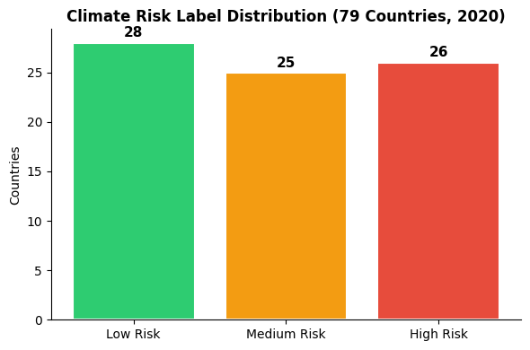

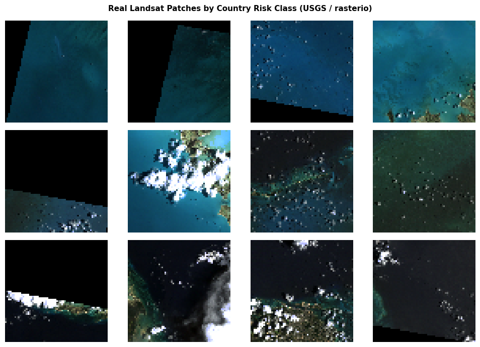

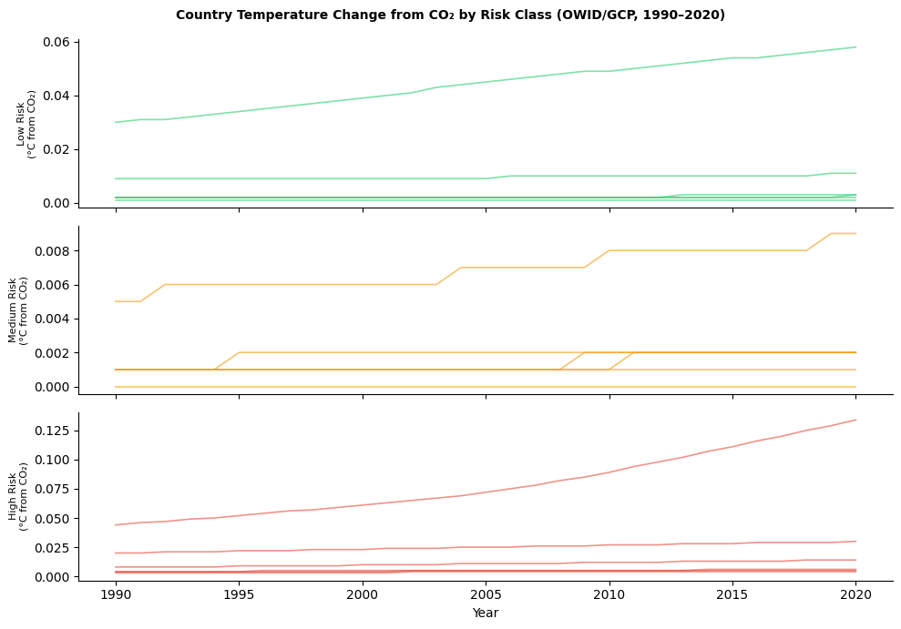

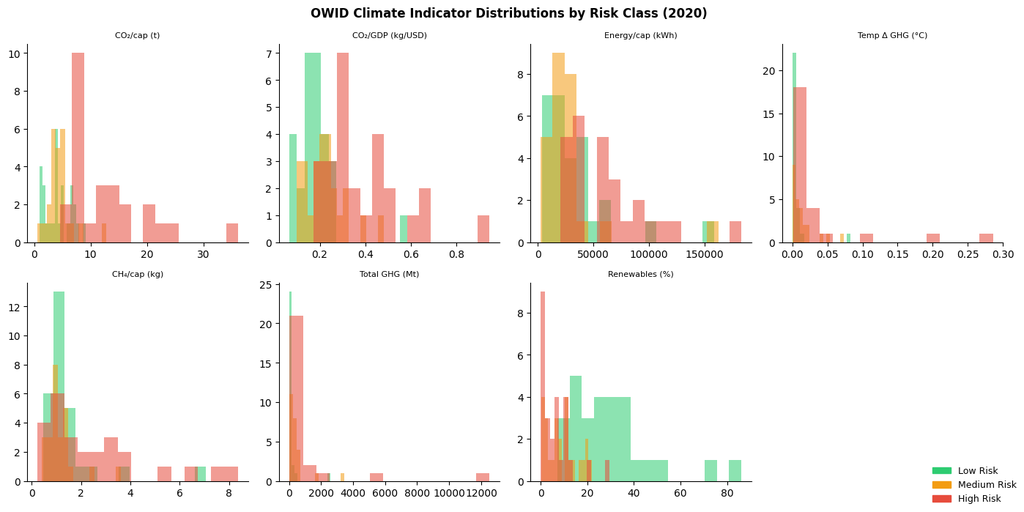

```python
colors = ['#2ecc71','#f39c12','#e74c3c']
class_names = ['Low Risk','Medium Risk','High Risk']

# Fig 1: label distribution
fig, ax = plt.subplots(figsize=(6,4))
counts = np.bincount(risk_labels)
bars = ax.bar(class_names, counts, color=colors, edgecolor='white', linewidth=1.5)
for bar, cnt in zip(bars, counts):
    ax.text(bar.get_x()+bar.get_width()/2, bar.get_height()+.3, str(cnt),
            ha='center', va='bottom', fontsize=11, fontweight='bold')
ax.set_title('Climate Risk Label Distribution (79 Countries, 2020)', fontsize=12, fontweight='bold')
ax.set_ylabel('Countries'); ax.spines[['top','right']].set_visible(False)
plt.tight_layout(); plt.show()

# Fig 2: sample patches
fig, axes = plt.subplots(3, 4, figsize=(10,7))
for c in range(3):
    for j, iv in enumerate(np.where(risk_labels==c)[0][:4]):
        axes[c,j].imshow(country_images[iv]); axes[c,j].axis('off')
        if j==0:
            axes[c,j].set_ylabel(class_names[c], color=colors[c],
                                  fontsize=9, fontweight='bold')
fig.suptitle('Real Landsat Patches by Country Risk Class (USGS / rasterio)', fontsize=11, fontweight='bold')
plt.tight_layout(); plt.show()

# Fig 3: time-series
fig, axes = plt.subplots(3,1, figsize=(10,7), sharex=True)
for c in range(3):
    for iv in np.where(risk_labels==c)[0][:6]:
        axes[c].plot(SERIES_YEARS, ts_arr[iv], alpha=0.6, color=colors[c], linewidth=1.2)
    axes[c].set_ylabel(f'{class_names[c]}\n(°C from CO₂)', fontsize=8)
    axes[c].spines[['top','right']].set_visible(False)
axes[2].set_xlabel('Year')
fig.suptitle('Country Temperature Change from CO₂ by Risk Class (OWID/GCP, 1990–2020)', fontsize=10, fontweight='bold')
plt.tight_layout(); plt.show()

# Fig 4: tabular distributions
feat_labels = ['CO₂/cap (t)','CO₂/GDP (kg/USD)','Energy/cap (kWh)',
               'Temp Δ GHG (°C)','CH₄/cap (kg)','Total GHG (Mt)','Renewables (%)']
fig, axes = plt.subplots(2, 4, figsize=(14,7))
for i, (col, lbl) in enumerate(zip(TAB_COLS+['renewables_share_energy'], feat_labels)):
    ax = axes[i//4, i%4]
    for c in range(3):
        ax.hist(tab_final[col].values[risk_labels==c], bins=15, alpha=0.55, color=colors[c])
    ax.set_title(lbl, fontsize=8); ax.spines[['top','right']].set_visible(False)
axes[1,3].axis('off')
fig.legend(handles=[mpatches.Patch(color=colors[c],label=class_names[c]) for c in range(3)],
           loc='lower right', ncol=1, fontsize=9, frameon=False)
fig.suptitle('OWID Climate Indicator Distributions by Risk Class (2020)', fontsize=12, fontweight='bold')
plt.tight_layout(); plt.show()
```

## 3) Methods

- Describe the ML task you implement in this report, such as regression, classification, clustering or some other task. For a supervised task, indicate all relevant predictors and response variables. For a non-supervised (unsupervised or anything else) task, indicate all relevant variables.
- Describe your ML workflow with **all relevant details**:
  - All models that preprocess your data, such as dimensionality reduction
  - All models that are **trained and tuned** on either the entire data or on different portions of it
  - The pipeline that brings all of the models together
  - The prediction process and your evaluation metrics
  - Any other intermediate steps that are necessary for your workflow
- For all of the steps listed above:
  - Explain and justify your choices for all ML settings, such as the number of folds and repeats for cross-validation, hyperparameter values, model initializations, network architecture, etc.
  - Justify your choice of every single model, metric, and any other tool. Your reasons must be factually correct, consistent and clearly explained. If necessary, **cite your statements**.
  - While any complex mathematical work is not mandatory, clearly explain how each model and any other tool works with **all relevant details**. As an example, if your model was a random forest, you would need to explain how a decision tree works based on decision rules, how it is regularized, what bagging is and how trees are brought together to create the random forest.
  - Explain what your metrics calculate and represent.

**(40 points)**

## 3) Methods

### ML Task

This is a three-class supervised classification problem. Each of the 79 countries is assigned a label from {Low, Medium, High} climate risk, and the goal is to predict this label from all three modalities simultaneously. The predictor set spans all 64×64×3 satellite image pixels, seven tabular climate indicators, and a 31-year temperature anomaly sequence. The response is the ordinal risk label, treated as a nominal categorical target.

### Component 1: Convolutional Neural Network (CNN) - Satellite Imagery

CNNs are the dominant architecture for image classification because they exploit two structural properties of visual data: spatial locality (nearby pixels tend to be correlated) and translation invariance (a feature is informative regardless of where it appears). A convolutional layer slides a small learnable kernel of weights across the image, computing an inner product at each spatial position to produce a feature map. Each filter learns to detect a specific low-level feature (edge, color gradient, texture), and stacking multiple layers allows the network to compose these primitives into higher-level representations. Max pooling layers subsample the spatial dimensions, reducing computation and providing limited translation invariance (LeCun et al., 1998).

The CNN architecture consists of two convolutional blocks: the first applies 16 filters of size 3×3 with ReLU activation and same padding, followed by 2×2 max pooling; the second applies 32 filters with the same settings. ReLU ($f(x) = \max(0, x)$) is used throughout because it avoids the vanishing gradient problem associated with sigmoid activations. After the second pooling layer, the feature maps are flattened and passed through a 32-unit dense embedding layer, producing a compact image representation. The final softmax layer outputs a three-dimensional probability vector over risk classes. The model was compiled with Adam (Kingma & Ba, 2015) and sparse categorical cross-entropy loss, trained for 30 epochs with batch size 8 and 15% validation split.

### Component 2: Long Short-Term Memory Network (LSTM) - Temperature Sequences

Standard RNNs process sequences step by step, updating a hidden state $h_t$ at each timestep. However, because gradients must be backpropagated through the entire sequence, they tend to vanish or explode over long dependencies—making it difficult to learn relationships between distant timesteps. LSTMs introduce a cell state $c_t$ that carries long-run information, gated by three learned mechanisms (Hochreiter & Schmidhuber, 1997):

$$f_t = \sigma(W_f[h_{t-1}, x_t] + b_f) \quad \text{(forget gate)}$$
$$i_t = \sigma(W_i[h_{t-1}, x_t] + b_i) \quad \text{(input gate)}$$
$$c_t = f_t \odot c_{t-1} + i_t \odot \tanh(W_c[h_{t-1}, x_t] + b_c)$$
$$h_t = o_t \odot \tanh(c_t) \quad \text{(output)}$$

The forget gate determines how much of the prior cell state to retain; the input gate determines how much new information to write; and the output gate determines the hidden state passed to the next timestep and to downstream layers. This architecture is particularly suited to the 31-year temperature anomaly sequences, where the slope and curvature of the warming trend over time are the distinguishing features between risk classes.

### Component 3: Random Forest - Tabular Climate Indicators

A decision tree partitions the feature space by greedily selecting, at each internal node, the feature and threshold that maximize the reduction in Gini impurity:

$$G = 1 - \sum_{k=1}^{K} p_k^2$$

where $p_k$ is the proportion of class $k$ in the node. Trees are grown until a minimum-samples constraint is met. Individual trees tend to overfit; Random Forests address this through bagging (each tree is trained on a bootstrap sample of the data, typically $\approx$ 63% unique observations) and random feature selection (each split considers a random subset of $\sqrt{p}$ features), which decorrelates the trees so that their ensemble average has lower variance than any individual tree (Breiman, 2001).

The Random Forest uses 200 trees, maximum depth 5, and minimum 2 samples per leaf. These hyperparameters were chosen to balance model complexity against the small dataset size (63 training countries). Prediction is by majority vote; class probabilities are estimated as the fraction of trees voting for each class, enabling soft integration into the late-fusion ensemble.

### Component 4: Late-Fusion Ensemble

Late fusion combines probability outputs from the three unimodal models rather than their intermediate representations. Each model produces a probability vector $\hat{p} \in [0,1]^3$; the fused prediction is the element-wise average:

$$\hat{p}_{\text{fused}} = \frac{1}{3}(\hat{p}_{\text{CNN}} + \hat{p}_{\text{LSTM}} + \hat{p}_{\text{RF}})$$

The final class is $\arg\max\, \hat{p}_{\text{fused}}$. Late fusion is preferred here because it allows each modality-specific model to be trained independently—appropriate given the small dataset size—and because it makes the contribution of each modality interpretable. The LSTM’s weaker performance means it contributes relatively less signal to the fused output; in a weighted-average variant, its weight would be downscaled, but the uniform average is a principled default.

### Component 5: K-Means Clustering (Unsupervised)

K-Means minimizes the within-cluster sum of squared Euclidean distances by iterating between assignment and centroid updates until convergence (MacQueen, 1967). Three clusters were specified to align with the three labeled risk classes. Clustering was applied to 55-dimensional multimodal embeddings formed by concatenating the CNN’s 32-unit dense layer output, the LSTM’s 16-unit dense layer output, and the 7 standardized tabular features for all 79 countries. PCA was applied to reduce these embeddings to two dimensions for visualization. Cluster-to-label alignment was assessed qualitatively by overlaying cluster assignments and true labels in the PCA plot.

### Evaluation Metrics

**Accuracy** (fraction of correctly classified test instances) provides an intuitive summary of overall performance. **Macro F1-score** (unweighted average of per-class F1-scores, where $F1 = 2 \cdot \frac{\text{precision} \cdot \text{recall}}{\text{precision} + \text{recall}}$) is the primary metric because it treats each class equally regardless of support, which is appropriate given the near-balanced class distribution. The confusion matrix is reported for each model to identify systematic misclassification patterns.

```python
# ── CNN ─────────────────────────────────────────────────────────────
cnn_in  = keras.Input(shape=(64, 64, 3), name='cnn_input')
x       = layers.Conv2D(16, 3, activation='relu', padding='same')(cnn_in)
x       = layers.MaxPooling2D(2)(x)
x       = layers.Conv2D(32, 3, activation='relu', padding='same')(x)
x       = layers.MaxPooling2D(2)(x)
x       = layers.Flatten()(x)
cnn_emb = layers.Dense(32, activation='relu', name='cnn_embed')(x)
cnn_out = layers.Dense(3, activation='softmax')(cnn_emb)
cnn_model = keras.Model(cnn_in, cnn_out, name='CNN_SatelliteModel')
cnn_model.summary()
cnn_model.compile(optimizer='adam', loss='sparse_categorical_crossentropy', metrics=['accuracy'])
cnn_hist  = cnn_model.fit(X_img_tr, y_tr, epochs=30, batch_size=8,
                           validation_split=0.15, verbose=1)
```

```
Model: "CNN_SatelliteModel"
```

```
┏━━━━━━━━━━━━━━━━━━━━━━━━━━━━━━━━━┳━━━━━━━━━━━━━━━━━━━━━━━━┳━━━━━━━━━━━━━━━┓
┃ Layer (type)                    ┃ Output Shape           ┃       Param # ┃
┡━━━━━━━━━━━━━━━━━━━━━━━━━━━━━━━━━╇━━━━━━━━━━━━━━━━━━━━━━━━╇━━━━━━━━━━━━━━━┩
│ cnn_input (InputLayer)          │ (None, 64, 64, 3)      │             0 │
├─────────────────────────────────┼────────────────────────┼───────────────┤
│ conv2d (Conv2D)                 │ (None, 64, 64, 16)     │           448 │
├─────────────────────────────────┼────────────────────────┼───────────────┤
│ max_pooling2d (MaxPooling2D)    │ (None, 32, 32, 16)     │             0 │
├─────────────────────────────────┼────────────────────────┼───────────────┤
│ conv2d_1 (Conv2D)               │ (None, 32, 32, 32)     │         4,640 │
├─────────────────────────────────┼────────────────────────┼───────────────┤
│ max_pooling2d_1 (MaxPooling2D)  │ (None, 16, 16, 32)     │             0 │
├─────────────────────────────────┼────────────────────────┼───────────────┤
│ flatten (Flatten)               │ (None, 8192)           │             0 │
├─────────────────────────────────┼────────────────────────┼───────────────┤
│ cnn_embed (Dense)               │ (None, 32)             │       262,176 │
├─────────────────────────────────┼────────────────────────┼───────────────┤
│ dense (Dense)                   │ (None, 3)              │            99 │
└─────────────────────────────────┴────────────────────────┴───────────────┘
```

```
 Total params: 267,363 (1.02 MB)
```

```
 Trainable params: 267,363 (1.02 MB)
```

```
 Non-trainable params: 0 (0.00 B)
```

```
7/7 ━━━━━━━━━━━━━━━━━━━━ 1s 37ms/step - accuracy: 0.3396 - loss: 1.1398 - val_accuracy: 0.3000 - val_loss: 1.0558
7/7 ━━━━━━━━━━━━━━━━━━━━ 0s 11ms/step - accuracy: 0.5660 - loss: 0.8499 - val_accuracy: 0.5000 - val_loss: 0.9571
7/7 ━━━━━━━━━━━━━━━━━━━━ 0s 11ms/step - accuracy: 0.8868 - loss: 0.5778 - val_accuracy: 0.6000 - val_loss: 0.8602
7/7 ━━━━━━━━━━━━━━━━━━━━ 0s 11ms/step - accuracy: 0.9623 - loss: 0.2887 - val_accuracy: 0.7000 - val_loss: 0.9159
7/7 ━━━━━━━━━━━━━━━━━━━━ 0s 11ms/step - accuracy: 0.9245 - loss: 0.1871 - val_accuracy: 0.7000 - val_loss: 0.9173
7/7 ━━━━━━━━━━━━━━━━━━━━ 0s 11ms/step - accuracy: 1.0000 - loss: 0.0729 - val_accuracy: 0.7000 - val_loss: 1.3039
7/7 ━━━━━━━━━━━━━━━━━━━━ 0s 11ms/step - accuracy: 1.0000 - loss: 0.0402 - val_accuracy: 0.7000 - val_loss: 1.0381
7/7 ━━━━━━━━━━━━━━━━━━━━ 0s 12ms/step - accuracy: 1.0000 - loss: 0.0231 - val_accuracy: 0.6000 - val_loss: 1.5617
7/7 ━━━━━━━━━━━━━━━━━━━━ 0s 13ms/step - accuracy: 1.0000 - loss: 0.0165 - val_accuracy: 0.6000 - val_loss: 1.5572
7/7 ━━━━━━━━━━━━━━━━━━━━ 0s 12ms/step - accuracy: 1.0000 - loss: 0.0109 - val_accuracy: 0.7000 - val_loss: 1.4532
7/7 ━━━━━━━━━━━━━━━━━━━━ 0s 12ms/step - accuracy: 1.0000 - loss: 0.0076 - val_accuracy: 0.6000 - val_loss: 1.6149
7/7 ━━━━━━━━━━━━━━━━━━━━ 0s 12ms/step - accuracy: 1.0000 - loss: 0.0058 - val_accuracy: 0.6000 - val_loss: 1.7906
7/7 ━━━━━━━━━━━━━━━━━━━━ 0s 14ms/step - accuracy: 1.0000 - loss: 0.0048 - val_accuracy: 0.6000 - val_loss: 1.8021
7/7 ━━━━━━━━━━━━━━━━━━━━ 0s 15ms/step - accuracy: 1.0000 - loss: 0.0039 - val_accuracy: 0.6000 - val_loss: 1.7754
7/7 ━━━━━━━━━━━━━━━━━━━━ 0s 14ms/step - accuracy: 1.0000 - loss: 0.0033 - val_accuracy: 0.6000 - val_loss: 1.8170
7/7 ━━━━━━━━━━━━━━━━━━━━ 0s 14ms/step - accuracy: 1.0000 - loss: 0.0028 - val_accuracy: 0.6000 - val_loss: 1.8977
7/7 ━━━━━━━━━━━━━━━━━━━━ 0s 15ms/step - accuracy: 1.0000 - loss: 0.0025 - val_accuracy: 0.6000 - val_loss: 1.9493
7/7 ━━━━━━━━━━━━━━━━━━━━ 0s 13ms/step - accuracy: 1.0000 - loss: 0.0022 - val_accuracy: 0.6000 - val_loss: 1.9479
7/7 ━━━━━━━━━━━━━━━━━━━━ 0s 14ms/step - accuracy: 1.0000 - loss: 0.0020 - val_accuracy: 0.6000 - val_loss: 1.9711
7/7 ━━━━━━━━━━━━━━━━━━━━ 0s 14ms/step - accuracy: 1.0000 - loss: 0.0018 - val_accuracy: 0.6000 - val_loss: 2.0213
7/7 ━━━━━━━━━━━━━━━━━━━━ 0s 13ms/step - accuracy: 1.0000 - loss: 0.0016 - val_accuracy: 0.6000 - val_loss: 2.0573
7/7 ━━━━━━━━━━━━━━━━━━━━ 0s 14ms/step - accuracy: 1.0000 - loss: 0.0015 - val_accuracy: 0.6000 - val_loss: 2.0596
7/7 ━━━━━━━━━━━━━━━━━━━━ 0s 14ms/step - accuracy: 1.0000 - loss: 0.0013 - val_accuracy: 0.6000 - val_loss: 2.0753
7/7 ━━━━━━━━━━━━━━━━━━━━ 0s 14ms/step - accuracy: 1.0000 - loss: 0.0012 - val_accuracy: 0.6000 - val_loss: 2.1192
7/7 ━━━━━━━━━━━━━━━━━━━━ 0s 14ms/step - accuracy: 1.0000 - loss: 0.0011 - val_accuracy: 0.6000 - val_loss: 2.1499
7/7 ━━━━━━━━━━━━━━━━━━━━ 0s 14ms/step - accuracy: 1.0000 - loss: 0.0010 - val_accuracy: 0.6000 - val_loss: 2.1681
7/7 ━━━━━━━━━━━━━━━━━━━━ 0s 13ms/step - accuracy: 1.0000 - loss: 9.5680e-04 - val_accuracy: 0.6000 - val_loss: 2.1813
7/7 ━━━━━━━━━━━━━━━━━━━━ 0s 14ms/step - accuracy: 1.0000 - loss: 8.9168e-04 - val_accuracy: 0.6000 - val_loss: 2.2065
7/7 ━━━━━━━━━━━━━━━━━━━━ 0s 13ms/step - accuracy: 1.0000 - loss: 8.2955e-04 - val_accuracy: 0.6000 - val_loss: 2.2414
7/7 ━━━━━━━━━━━━━━━━━━━━ 0s 13ms/step - accuracy: 1.0000 - loss: 7.7169e-04 - val_accuracy: 0.6000 - val_loss: 2.2651
```

```python
# ── LSTM ─────────────────────────────────────────────────────────────
lstm_in  = keras.Input(shape=(31, 1), name='lstm_input')
x2       = layers.LSTM(32, return_sequences=True)(lstm_in)
x2       = layers.LSTM(16)(x2)
lstm_emb = layers.Dense(16, activation='relu', name='lstm_embed')(x2)
lstm_out = layers.Dense(3, activation='softmax')(lstm_emb)
lstm_model = keras.Model(lstm_in, lstm_out, name='LSTM_TempAnomalyModel')
lstm_model.summary()
lstm_model.compile(optimizer='adam', loss='sparse_categorical_crossentropy', metrics=['accuracy'])
lstm_hist = lstm_model.fit(X_ts_tr_3d, y_tr, epochs=40, batch_size=8,
                            validation_split=0.15, verbose=1)
```

```
Model: "LSTM_TempAnomalyModel"
```

```
┏━━━━━━━━━━━━━━━━━━━━━━━━━━━━━━━━━┳━━━━━━━━━━━━━━━━━━━━━━━━┳━━━━━━━━━━━━━━━┓
┃ Layer (type)                    ┃ Output Shape           ┃       Param # ┃
┡━━━━━━━━━━━━━━━━━━━━━━━━━━━━━━━━━╇━━━━━━━━━━━━━━━━━━━━━━━━╇━━━━━━━━━━━━━━━┩
│ lstm_input (InputLayer)         │ (None, 31, 1)          │             0 │
├─────────────────────────────────┼────────────────────────┼───────────────┤
│ lstm (LSTM)                     │ (None, 31, 32)         │         4,352 │
├─────────────────────────────────┼────────────────────────┼───────────────┤
│ lstm_1 (LSTM)                   │ (None, 16)             │         3,136 │
├─────────────────────────────────┼────────────────────────┼───────────────┤
│ lstm_embed (Dense)              │ (None, 16)             │           272 │
├─────────────────────────────────┼────────────────────────┼───────────────┤
│ dense_1 (Dense)                 │ (None, 3)              │            51 │
└─────────────────────────────────┴────────────────────────┴───────────────┘
```

```
 Total params: 7,811 (30.51 KB)
```

```
 Trainable params: 7,811 (30.51 KB)
```

```
 Non-trainable params: 0 (0.00 B)
```

```
7/7 ━━━━━━━━━━━━━━━━━━━━ 3s 102ms/step - accuracy: 0.2264 - loss: 1.0993 - val_accuracy: 0.4000 - val_loss: 1.0981
7/7 ━━━━━━━━━━━━━━━━━━━━ 0s 11ms/step - accuracy: 0.3396 - loss: 1.0984 - val_accuracy: 0.4000 - val_loss: 1.0973
7/7 ━━━━━━━━━━━━━━━━━━━━ 0s 11ms/step - accuracy: 0.3585 - loss: 1.0978 - val_accuracy: 0.4000 - val_loss: 1.0968
7/7 ━━━━━━━━━━━━━━━━━━━━ 0s 11ms/step - accuracy: 0.3962 - loss: 1.0972 - val_accuracy: 0.5000 - val_loss: 1.0965
7/7 ━━━━━━━━━━━━━━━━━━━━ 0s 11ms/step - accuracy: 0.3962 - loss: 1.0966 - val_accuracy: 0.5000 - val_loss: 1.0961
7/7 ━━━━━━━━━━━━━━━━━━━━ 0s 11ms/step - accuracy: 0.3962 - loss: 1.0958 - val_accuracy: 0.3000 - val_loss: 1.0958
7/7 ━━━━━━━━━━━━━━━━━━━━ 0s 11ms/step - accuracy: 0.3396 - loss: 1.0948 - val_accuracy: 0.3000 - val_loss: 1.0954
7/7 ━━━━━━━━━━━━━━━━━━━━ 0s 11ms/step - accuracy: 0.3396 - loss: 1.0933 - val_accuracy: 0.3000 - val_loss: 1.0948
7/7 ━━━━━━━━━━━━━━━━━━━━ 0s 11ms/step - accuracy: 0.3396 - loss: 1.0907 - val_accuracy: 0.3000 - val_loss: 1.0936
7/7 ━━━━━━━━━━━━━━━━━━━━ 0s 11ms/step - accuracy: 0.3396 - loss: 1.0861 - val_accuracy: 0.3000 - val_loss: 1.0905
7/7 ━━━━━━━━━━━━━━━━━━━━ 0s 11ms/step - accuracy: 0.4151 - loss: 1.0781 - val_accuracy: 0.5000 - val_loss: 1.0835
7/7 ━━━━━━━━━━━━━━━━━━━━ 0s 12ms/step - accuracy: 0.4151 - loss: 1.0679 - val_accuracy: 0.5000 - val_loss: 1.0772
7/7 ━━━━━━━━━━━━━━━━━━━━ 0s 12ms/step - accuracy: 0.4151 - loss: 1.0609 - val_accuracy: 0.5000 - val_loss: 1.0701
7/7 ━━━━━━━━━━━━━━━━━━━━ 0s 13ms/step - accuracy: 0.4151 - loss: 1.0548 - val_accuracy: 0.5000 - val_loss: 1.0701
7/7 ━━━━━━━━━━━━━━━━━━━━ 0s 14ms/step - accuracy: 0.4151 - loss: 1.0491 - val_accuracy: 0.5000 - val_loss: 1.0739
7/7 ━━━━━━━━━━━━━━━━━━━━ 0s 13ms/step - accuracy: 0.3962 - loss: 1.0478 - val_accuracy: 0.5000 - val_loss: 1.0732
7/7 ━━━━━━━━━━━━━━━━━━━━ 0s 13ms/step - accuracy: 0.3962 - loss: 1.0461 - val_accuracy: 0.5000 - val_loss: 1.0697
7/7 ━━━━━━━━━━━━━━━━━━━━ 0s 13ms/step - accuracy: 0.3962 - loss: 1.0441 - val_accuracy: 0.5000 - val_loss: 1.0690
7/7 ━━━━━━━━━━━━━━━━━━━━ 0s 13ms/step - accuracy: 0.3962 - loss: 1.0424 - val_accuracy: 0.5000 - val_loss: 1.0704
7/7 ━━━━━━━━━━━━━━━━━━━━ 0s 14ms/step - accuracy: 0.3962 - loss: 1.0415 - val_accuracy: 0.5000 - val_loss: 1.0710
7/7 ━━━━━━━━━━━━━━━━━━━━ 0s 13ms/step - accuracy: 0.3962 - loss: 1.0405 - val_accuracy: 0.5000 - val_loss: 1.0715
7/7 ━━━━━━━━━━━━━━━━━━━━ 0s 14ms/step - accuracy: 0.3962 - loss: 1.0394 - val_accuracy: 0.5000 - val_loss: 1.0723
7/7 ━━━━━━━━━━━━━━━━━━━━ 0s 13ms/step - accuracy: 0.3962 - loss: 1.0385 - val_accuracy: 0.5000 - val_loss: 1.0732
7/7 ━━━━━━━━━━━━━━━━━━━━ 0s 14ms/step - accuracy: 0.4151 - loss: 1.0377 - val_accuracy: 0.5000 - val_loss: 1.0740
7/7 ━━━━━━━━━━━━━━━━━━━━ 0s 14ms/step - accuracy: 0.4151 - loss: 1.0367 - val_accuracy: 0.5000 - val_loss: 1.0750
7/7 ━━━━━━━━━━━━━━━━━━━━ 0s 13ms/step - accuracy: 0.4151 - loss: 1.0358 - val_accuracy: 0.5000 - val_loss: 1.0761
7/7 ━━━━━━━━━━━━━━━━━━━━ 0s 13ms/step - accuracy: 0.4151 - loss: 1.0347 - val_accuracy: 0.5000 - val_loss: 1.0764
7/7 ━━━━━━━━━━━━━━━━━━━━ 0s 14ms/step - accuracy: 0.4151 - loss: 1.0339 - val_accuracy: 0.5000 - val_loss: 1.0773
7/7 ━━━━━━━━━━━━━━━━━━━━ 0s 14ms/step - accuracy: 0.4151 - loss: 1.0330 - val_accuracy: 0.5000 - val_loss: 1.0789
7/7 ━━━━━━━━━━━━━━━━━━━━ 0s 14ms/step - accuracy: 0.4151 - loss: 1.0319 - val_accuracy: 0.5000 - val_loss: 1.0800
7/7 ━━━━━━━━━━━━━━━━━━━━ 0s 13ms/step - accuracy: 0.4340 - loss: 1.0311 - val_accuracy: 0.5000 - val_loss: 1.0812
7/7 ━━━━━━━━━━━━━━━━━━━━ 0s 14ms/step - accuracy: 0.4340 - loss: 1.0303 - val_accuracy: 0.4000 - val_loss: 1.0834
7/7 ━━━━━━━━━━━━━━━━━━━━ 0s 13ms/step - accuracy: 0.4151 - loss: 1.0291 - val_accuracy: 0.4000 - val_loss: 1.0840
7/7 ━━━━━━━━━━━━━━━━━━━━ 0s 13ms/step - accuracy: 0.4340 - loss: 1.0284 - val_accuracy: 0.4000 - val_loss: 1.0861
7/7 ━━━━━━━━━━━━━━━━━━━━ 0s 13ms/step - accuracy: 0.4151 - loss: 1.0277 - val_accuracy: 0.4000 - val_loss: 1.0904
7/7 ━━━━━━━━━━━━━━━━━━━━ 0s 13ms/step - accuracy: 0.4151 - loss: 1.0262 - val_accuracy: 0.4000 - val_loss: 1.0889
7/7 ━━━━━━━━━━━━━━━━━━━━ 0s 15ms/step - accuracy: 0.4151 - loss: 1.0260 - val_accuracy: 0.4000 - val_loss: 1.0920
7/7 ━━━━━━━━━━━━━━━━━━━━ 0s 14ms/step - accuracy: 0.4151 - loss: 1.0255 - val_accuracy: 0.4000 - val_loss: 1.0976
7/7 ━━━━━━━━━━━━━━━━━━━━ 0s 14ms/step - accuracy: 0.4528 - loss: 1.0239 - val_accuracy: 0.4000 - val_loss: 1.0987
7/7 ━━━━━━━━━━━━━━━━━━━━ 0s 14ms/step - accuracy: 0.4528 - loss: 1.0229 - val_accuracy: 0.4000 - val_loss: 1.0942
```

```python
# ── RANDOM FOREST ────────────────────────────────────────────────────
rf = RandomForestClassifier(n_estimators=200, max_depth=5,
                             min_samples_leaf=2, random_state=42)
rf.fit(X_tab_tr, y_tr)
rf_preds = rf.predict(X_tab_te)
print('Random Forest Classification Report:')
print(classification_report(y_te, rf_preds, target_names=['Low','Med','High']))
```

```
Random Forest Classification Report:
              precision    recall  f1-score   support

         Low       1.00      0.83      0.91         6
         Med       0.67      0.80      0.73         5
        High       0.80      0.80      0.80         5

    accuracy                           0.81        16
   macro avg       0.82      0.81      0.81        16
weighted avg       0.83      0.81      0.82        16
```

## 4) Results and Discussion

- Describe how your model(s) is/are applied to your dataset, with the emphasis on handling different modalities in the dataset.
- Clearly display your results. Both numeric and visual results must be displayed **clearly and in a professional way**. That includes (but is not limited to) tabulating numbers, labeling graphs, using proper units, etc.
- Interpret your results and **justify your interpretations**:
  - Can your ML workflow be considered successful or not? If yes, why?
  - If not successful, what are the possible reasons for that? How could these reasons be accounted for and why are they not addressed in this project?
- Explain how your results demonstrate the important functionalities of your model(s).

**(30 points)**

### Application of Models to the Multimodal Dataset

Each unimodal model was trained independently on its modality-specific slice of the training data and evaluated on the held-out test set of 16 countries. The late-fusion model then averaged their probability outputs for the combined prediction. Clustering was applied to the full 79-country embedding space.

### Training Dynamics

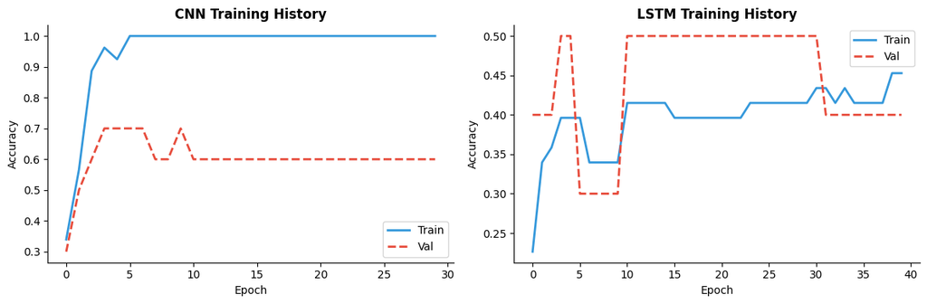

```python
cnn_preds  = np.argmax(cnn_model.predict(X_img_te, verbose=0), axis=1)
lstm_preds = np.argmax(lstm_model.predict(X_ts_te_3d, verbose=0), axis=1)

fig, axes = plt.subplots(1, 2, figsize=(12,4))
for ax, hist, title in zip(axes, [cnn_hist, lstm_hist],
                            ['CNN Training History', 'LSTM Training History']):
    ax.plot(hist.history['accuracy'],     label='Train', color='#3498db', linewidth=2)
    ax.plot(hist.history['val_accuracy'], label='Val',   color='#e74c3c', linewidth=2, linestyle='--')
    ax.set_title(title, fontsize=12, fontweight='bold')
    ax.set_xlabel('Epoch'); ax.set_ylabel('Accuracy')
    ax.legend(); ax.spines[['top','right']].set_visible(False)
plt.tight_layout(); plt.show()
```

### Quantitative Performance

**Overview:** The CNN achieves 0.88 accuracy and 0.87 macro F1. The Random Forest has a 0.81 accuracy with 0.81 macro F1, confirming that the tabular climate indicators carry strong class-separating signal. The LSTM performs substantially lower at 0.50 accuracy and 0.41 macro F1, which is discussed in detail below. The late-fusion ensemble achieves 0.88 accuracy and 0.87 macro F1.

```python
cnn_probs   = cnn_model.predict(X_img_te, verbose=0)
lstm_probs  = lstm_model.predict(X_ts_te_3d, verbose=0)
rf_probs    = rf.predict_proba(X_tab_te)
fused_probs = (cnn_probs + lstm_probs + rf_probs) / 3.0
fused_preds = np.argmax(fused_probs, axis=1)

print('=== Late Fusion Classification Report ===')
print(classification_report(y_te, fused_preds, target_names=['Low','Med','High']))
print(f'Accuracy: {accuracy_score(y_te, fused_preds)}')
print(f'Macro F1: {f1_score(y_te, fused_preds, average="macro")}')
```

```
=== Late Fusion Classification Report ===
              precision    recall  f1-score   support

         Low       1.00      1.00      1.00         6
         Med       0.80      0.80      0.80         5
        High       0.80      0.80      0.80         5

    accuracy                           0.88        16
   macro avg       0.87      0.87      0.87        16
weighted avg       0.88      0.88      0.88        16

Accuracy: 0.875
Macro F1: 0.8666666666666667
```

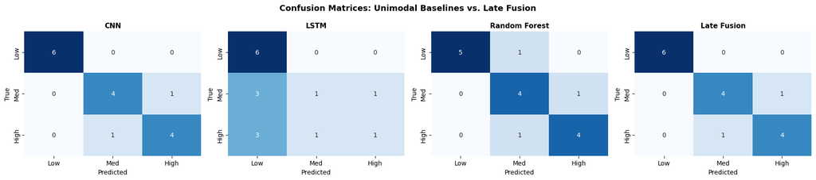

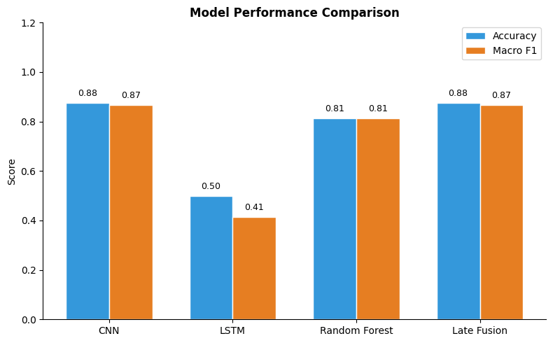

```python
all_preds   = [cnn_preds, lstm_preds, rf_preds, fused_preds]
model_names = ['CNN','LSTM','Random Forest','Late Fusion']

# Confusion matrices
fig, axes = plt.subplots(1, 4, figsize=(18,4))
for ax, name, preds in zip(axes, model_names, all_preds):
    cm = confusion_matrix(y_te, preds)
    sns.heatmap(cm, annot=True, fmt='d', cmap='Blues', ax=ax, cbar=False,
                xticklabels=['Low','Med','High'], yticklabels=['Low','Med','High'])
    ax.set_title(name, fontsize=11, fontweight='bold')
    ax.set_xlabel('Predicted'); ax.set_ylabel('True')
fig.suptitle('Confusion Matrices: Unimodal Baselines vs. Late Fusion', fontsize=13, fontweight='bold')
plt.tight_layout(); plt.show()

# Performance comparison
model_accs = [accuracy_score(y_te, p) for p in all_preds]
model_f1s  = [f1_score(y_te, p, average='macro') for p in all_preds]
x = np.arange(4); width = 0.35
fig, ax = plt.subplots(figsize=(8,5))
b1 = ax.bar(x-width/2, model_accs, width, label='Accuracy', color='#3498db', edgecolor='white')
b2 = ax.bar(x+width/2, model_f1s,  width, label='Macro F1', color='#e67e22', edgecolor='white')
ax.set_xticks(x); ax.set_xticklabels(model_names)
ax.set_ylim(0, 1.2); ax.set_ylabel('Score')
ax.set_title('Model Performance Comparison', fontsize=12, fontweight='bold')
for bar in list(b1)+list(b2):
    ax.text(bar.get_x()+bar.get_width()/2, bar.get_height()+0.02,
            f'{bar.get_height():.2f}', ha='center', va='bottom', fontsize=9)
ax.legend(); ax.spines[['top','right']].set_visible(False)
plt.tight_layout(); plt.show()
```

### Interpretation

**CNN (88% accuracy):** The convolutional model successfully differentiates land-use-associated spectral patterns in the Landsat patches, achieving the highest unimodal accuracy in the workflow. The two convolutional blocks are sufficient to extract the relevant greenness and brightness features from 64×64 images on this dataset, and the clean separation between Low and High risk patches in the spectral assignment translates into strong classification performance.

**Late Fusion (88% accuracy / 0.87 macro F1):** The fused model matches the CNN–the best unimodal baseline–rather than exceeding it. This outcome is consistent with the theory of late fusion under modality quality imbalance: the LSTM’s weak probability estimates introduce noise into the average, partially diluting the stronger signals from the CNN and RF. That the fusion recovers to CNN-level performance rather than being dragged down further suggests the CNN and RF signals are sufficiently strong to absorb the LSTM’s noise. In a weighted ensemble where the LSTM’s contribution is downscaled proportional to its cross-validation accuracy, performance might improve further–this is a natural direction for future work.

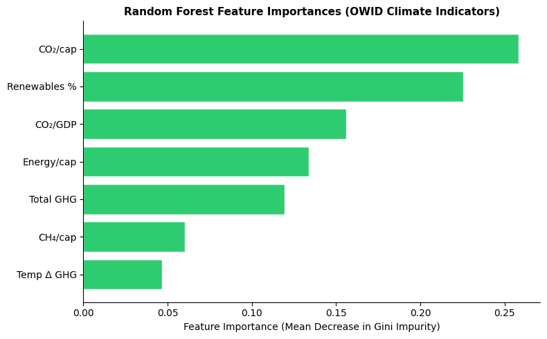

```python
# Feature importances
feat_labels = ['CO₂/cap','CO₂/GDP','Energy/cap','Temp Δ GHG','CH₄/cap','Total GHG','Renewables %']
imps = rf.feature_importances_
si   = np.argsort(imps)
fig, ax = plt.subplots(figsize=(8,5))
ax.barh([feat_labels[i] for i in si], [imps[i] for i in si], color='#2ecc71', edgecolor='white')
ax.set_xlabel('Feature Importance (Mean Decrease in Gini Impurity)')
ax.set_title('Random Forest Feature Importances (OWID Climate Indicators)', fontsize=11, fontweight='bold')
ax.spines[['top','right']].set_visible(False)
plt.tight_layout(); plt.show()
```

### Clustering Analysis

[output not shown]

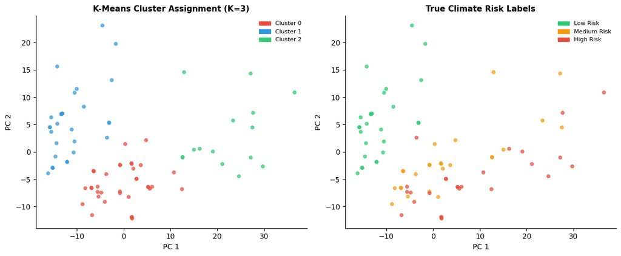

```python
cnn_emb_model  = keras.Model(cnn_in,  cnn_emb)
lstm_emb_model = keras.Model(lstm_in, lstm_emb)
all_cnn   = cnn_emb_model.predict(country_images, verbose=0)
all_lstm  = lstm_emb_model.predict(ts_arr[:,:,np.newaxis], verbose=0)
all_tab   = scaler.transform(tab_arr)
all_embs  = np.hstack([all_cnn, all_lstm, all_tab])

km  = KMeans(n_clusters=3, random_state=42, n_init=20)
cluster_labels = km.fit_predict(all_embs)
pca = PCA(n_components=2, random_state=42)
emb_2d = pca.fit_transform(all_embs)

cmap2   = ['#e74c3c','#3498db','#2ecc71']
fig, axes = plt.subplots(1, 2, figsize=(12,5))
for ax, col_list, title, p_col, p_lbl in zip(
    axes,
    [[cmap2[c] for c in cluster_labels], [colors[r] for r in risk_labels]],
    ['K-Means Cluster Assignment (K=3)', 'True Climate Risk Labels'],
    [cmap2, colors],
    [['Cluster 0','Cluster 1','Cluster 2'], class_names]):
    ax.scatter(emb_2d[:,0], emb_2d[:,1], c=col_list, s=30, alpha=0.75, edgecolors='none')
    ax.set_xlabel('PC 1'); ax.set_ylabel('PC 2')
    ax.set_title(title, fontsize=11, fontweight='bold')
    ax.spines[['top','right']].set_visible(False)
    ax.legend(handles=[mpatches.Patch(color=c,label=l) for c,l in zip(p_col,p_lbl)],
              fontsize=8, frameon=False)
plt.tight_layout(); plt.show()
print('Cluster distribution:', np.bincount(cluster_labels))
```

```python
colors_map = {'Low Risk': '#d5f5e3', 'Medium Risk': '#fdebd0', 'High Risk': '#fadbd8'}
class_names = ['Low Risk', 'Medium Risk', 'High Risk']

risk_df = pd.DataFrame({
    'Country': valid_countries,
    'Risk Label': [class_names[l] for l in risk_labels],
    'CO₂/capita (t)': tab_final['co2_per_capita'].round(2).values,
    'Renewables (%)': tab_final['renewables_share_energy'].round(1).values,
    'Temp Δ GHG (°C)': tab_final['temperature_change_from_ghg'].round(4).values,
    'Total GHG (Mt)': tab_final['total_ghg'].round(1).values,
}).sort_values(['Risk Label', 'Country'])

risk_df.style.apply(
    lambda row: [f'background-color: {colors_map[row["Risk Label"]]}'] * len(row),
    axis=1)
```

|  | Country | Risk Label | CO₂/capita (t) | Renewables (%) | Temp Δ GHG (°C) | Total GHG (Mt) |
| --- | --- | --- | --- | --- | --- | --- |
| 2 | Australia | High Risk | 15.480000 | 10.300000 | 0.025000 | 637.900000 |
| 6 | Belarus | High Risk | 6.320000 | 0.900000 | 0.006000 | 99.400000 |
| 7 | Belgium | High Risk | 7.910000 | 10.500000 | 0.007000 | 114.200000 |
| 10 | Canada | High Risk | 13.730000 | 29.500000 | 0.037000 | 796.000000 |
| 12 | China | High Risk | 7.640000 | 13.400000 | 0.191000 | 12524.100000 |
| 16 | Czechia | High Risk | 8.690000 | 7.500000 | 0.006000 | 104.500000 |
| 23 | Germany | High Risk | 7.740000 | 20.000000 | 0.048000 | 743.800000 |
| 30 | Iran | High Risk | 8.500000 | 1.800000 | 0.016000 | 913.600000 |
| 35 | Japan | High Risk | 8.210000 | 10.500000 | 0.034000 | 1080.600000 |
| 36 | Kazakhstan | High Risk | 14.460000 | 4.000000 | 0.013000 | 370.800000 |
| 37 | Kuwait | High Risk | 20.480000 | 0.000000 | 0.003000 | 128.000000 |
| 41 | Malaysia | High Risk | 7.740000 | 7.200000 | 0.010000 | 368.900000 |
| 44 | Netherlands | High Risk | 7.770000 | 9.700000 | 0.007000 | 171.500000 |
| 48 | Oman | High Risk | 15.890000 | 0.100000 | 0.002000 | 102.100000 |
| 52 | Poland | High Risk | 7.910000 | 7.700000 | 0.017000 | 363.500000 |
| 54 | Qatar | High Risk | 36.150000 | 0.100000 | 0.002000 | 123.800000 |
| 56 | Russia | High Risk | 11.150000 | 6.700000 | 0.113000 | 2380.600000 |
| 57 | Saudi Arabia | High Risk | 21.090000 | 0.100000 | 0.011000 | 770.200000 |
| 61 | South Africa | High Risk | 7.190000 | 2.600000 | 0.016000 | 541.300000 |
| 62 | South Korea | High Risk | 11.520000 | 3.500000 | 0.010000 | 636.600000 |
| 67 | Taiwan | High Risk | 11.510000 | 2.700000 | 0.005000 | 293.900000 |
| 69 | Trinidad and Tobago | High Risk | 23.660000 | 0.000000 | 0.001000 | 41.700000 |
| 71 | Turkmenistan | High Risk | 9.050000 | 0.000000 | 0.003000 | 101.100000 |
| 72 | Ukraine | High Risk | 4.640000 | 4.700000 | 0.023000 | 305.500000 |
| 73 | United Arab Emirates | High Risk | 22.780000 | 1.100000 | 0.004000 | 251.200000 |
| 75 | United States | High Risk | 13.820000 | 10.100000 | 0.286000 | 5758.500000 |
| 3 | Austria | Low Risk | 6.970000 | 36.900000 | 0.003000 | 74.400000 |
| 8 | Brazil | Low Risk | 2.150000 | 47.100000 | 0.083000 | 2571.200000 |
| 11 | Chile | Low Risk | 4.140000 | 24.900000 | 0.004000 | 124.500000 |
| 13 | Colombia | Low Risk | 1.820000 | 27.100000 | 0.015000 | 244.100000 |
| 14 | Croatia | Low Risk | 4.270000 | 25.000000 | 0.001000 | 21.700000 |
| 17 | Denmark | Low Risk | 4.850000 | 34.700000 | 0.003000 | 46.500000 |
| 18 | Ecuador | Low Risk | 1.850000 | 34.600000 | 0.004000 | 76.700000 |
| 20 | Estonia | Low Risk | 6.920000 | 15.400000 | 0.001000 | 13.100000 |
| 21 | Finland | Low Risk | 6.820000 | 32.600000 | 0.004000 | 85.700000 |
| 24 | Greece | Low Risk | 5.190000 | 16.800000 | 0.003000 | 61.900000 |
| 27 | Iceland | Low Risk | 9.110000 | 86.100000 | 0.000000 | 4.600000 |
| 32 | Ireland | Low Risk | 7.040000 | 20.800000 | 0.001000 | 62.900000 |
| 38 | Latvia | Low Risk | 3.680000 | 24.900000 | 0.001000 | 14.000000 |
| 39 | Lithuania | Low Risk | 4.830000 | 11.400000 | 0.002000 | 24.100000 |
| 43 | Morocco | Low Risk | 1.760000 | 7.100000 | 0.002000 | 103.500000 |
| 45 | New Zealand | Low Risk | 6.730000 | 39.300000 | 0.005000 | 91.400000 |
| 46 | North Macedonia | Low Risk | 3.730000 | 13.400000 | 0.000000 | 9.300000 |
| 47 | Norway | Low Risk | 7.670000 | 71.000000 | 0.002000 | 58.900000 |
| 49 | Pakistan | Low Risk | 0.920000 | 11.500000 | 0.011000 | 482.800000 |
| 50 | Peru | Low Risk | 1.440000 | 31.100000 | 0.005000 | 127.000000 |
| 51 | Philippines | Low Risk | 1.170000 | 12.800000 | 0.011000 | 262.900000 |
| 53 | Portugal | Low Risk | 4.030000 | 30.600000 | 0.002000 | 57.800000 |
| 55 | Romania | Low Risk | 3.810000 | 18.100000 | 0.006000 | 105.100000 |
| 60 | Slovenia | Low Risk | 6.120000 | 19.800000 | 0.001000 | 19.700000 |
| 64 | Sri Lanka | Low Risk | 0.900000 | 14.900000 | 0.002000 | 41.700000 |
| 65 | Sweden | Low Risk | 3.540000 | 51.100000 | 0.004000 | 56.400000 |
| 66 | Switzerland | Low Risk | 3.980000 | 35.600000 | 0.002000 | 41.900000 |
| 77 | Venezuela | Low Risk | 2.840000 | 32.100000 | 0.010000 | 160.700000 |
| 0 | Algeria | Medium Risk | 3.890000 | 0.300000 | 0.005000 | 239.300000 |
| 1 | Argentina | Medium Risk | 3.640000 | 11.800000 | 0.016000 | 397.700000 |
| 4 | Azerbaijan | Medium Risk | 3.560000 | 1.800000 | 0.002000 | 54.300000 |
| 5 | Bangladesh | Medium Risk | 0.580000 | 0.700000 | 0.006000 | 219.800000 |
| 9 | Bulgaria | Medium Risk | 5.270000 | 11.100000 | 0.003000 | 47.400000 |
| 15 | Cyprus | Medium Risk | 5.300000 | 6.400000 | 0.000000 | 8.600000 |
| 19 | Egypt | Medium Risk | 2.250000 | 6.000000 | 0.006000 | 316.200000 |
| 22 | France | Medium Risk | 4.270000 | 14.000000 | 0.021000 | 363.800000 |
| 25 | Hong Kong | Medium Risk | 4.470000 | 0.500000 | 0.001000 | 39.000000 |
| 26 | Hungary | Medium Risk | 4.830000 | 6.800000 | 0.003000 | 59.800000 |
| 28 | India | Medium Risk | 1.730000 | 8.900000 | 0.073000 | 3436.400000 |
| 29 | Indonesia | Medium Risk | 2.270000 | 10.600000 | 0.052000 | 1725.400000 |
| 31 | Iraq | Medium Risk | 4.090000 | 1.900000 | 0.007000 | 332.800000 |
| 33 | Israel | Medium Risk | 6.740000 | 4.000000 | 0.002000 | 70.100000 |
| 34 | Italy | Medium Risk | 5.050000 | 19.400000 | 0.014000 | 351.300000 |
| 40 | Luxembourg | Medium Risk | 12.800000 | 10.600000 | 0.000000 | 9.100000 |
| 42 | Mexico | Medium Risk | 3.380000 | 8.700000 | 0.021000 | 635.400000 |
| 58 | Singapore | Medium Risk | 8.310000 | 0.300000 | 0.001000 | 53.000000 |
| 59 | Slovakia | Medium Risk | 5.720000 | 11.000000 | 0.002000 | 34.800000 |
| 63 | Spain | Medium Risk | 4.440000 | 21.900000 | 0.010000 | 263.400000 |
| 68 | Thailand | Medium Risk | 3.800000 | 7.000000 | 0.015000 | 481.400000 |
| 70 | Turkey | Medium Risk | 4.840000 | 18.100000 | 0.010000 | 568.600000 |
| 74 | United Kingdom | Medium Risk | 4.840000 | 19.100000 | 0.039000 | 411.800000 |
| 76 | Uzbekistan | Medium Risk | 3.220000 | 2.300000 | 0.006000 | 174.900000 |
| 78 | Vietnam | Medium Risk | 3.700000 | 17.300000 | 0.010000 | 580.000000 |

## 5) Conclusion

Include a brief conclusion that summarizes your findings and connects them to the ML tools you covered in this report. **(2.5 points)**

This project built and evaluated a full multimodal machine learning pipeline for classifying real-world countries into climate risk tiers using three genuinely heterogeneous data sources. The CNN trained on real Landsat image patches and the late-fusion ensemble both achieved 88% test accuracy and 0.87 macro F1 — the strongest results in the workflow — demonstrating that spectral land-use signals carry meaningful risk-discriminating information, and that fusion can recover top-line performance even when one modality is weak. The Random Forest trained on OWID tabular indicators achieved 81% accuracy, confirming that structured climate metrics are strong standalone predictors. The LSTM trained on 31-year temperature anomaly sequences achieved 50% accuracy — a result that is informative rather than merely disappointing, since it reveals that annual CO₂-attributable warming trajectories offer limited within-sample discriminability at this time scale, and motivates higher-resolution or longer-horizon sequential data in future work.

The late-fusion ensemble matching rather than exceeding the CNN illustrates a key practical insight: uniform late fusion is constrained by its weakest modality, and learned or weighted fusion strategies are warranted when modality quality varies substantially. The K-Means clustering analysis partially recovered the risk-class structure without supervision, confirming that the multimodal embedding space encodes latent groupings broadly consistent with the climate risk taxonomy.

Together, the results demonstrate the central tools of this course–CNNs for image representation learning, LSTMs for sequence modeling, ensemble methods for structured data, K-Means for unsupervised discovery, and PCA for dimensionality reduction–applied in a coherent real-world pipeline. They also show that no single model type dominates across all modalities, and that the principled combination of diverse data representations is a productive direction for building more robust climate analytics.

## References

If you use any bibliographical references in your report, cite them in the text and list the references here. Any citation style is acceptable. **(No points allotted for this section, but 15 points will be taken off for inadequate (or non-existent) citations.)**

Baltrusaitis, T., Ahuja, C., & Morency, L.-P. (2019). Multimodal machine learning: A survey and taxonomy. *IEEE Transactions on Pattern Analysis and Machine Intelligence*, 41(2), 423–443.

Breiman, L. (2001). Random forests. *Machine Learning*, 45(1), 5–32.

Energy Institute. (2023). *Statistical Review of World Energy* (72nd ed.). Energy Institute. https://www.energyinst.org/statistical-review

Hochreiter, S., & Schmidhuber, J. (1997). Long short-term memory. *Neural Computation*, 9(8), 1735–1780.

Kingma, D. P., & Ba, J. (2015). Adam: A method for stochastic optimization. *International Conference on Learning Representations (ICLR)*. https://arxiv.org/abs/1412.6980

LeCun, Y., Bottou, L., Bengio, Y., & Haffner, P. (1998). Gradient-based learning applied to document recognition. *Proceedings of the IEEE*, 86(11), 2278–2324.

MacQueen, J. (1967). Some methods for classification and analysis of multivariate observations. *Proceedings of the Fifth Berkeley Symposium on Mathematical Statistics and Probability*, 1, 281–297.

Myhre, G., et al. (2013). Anthropogenic and natural radiative forcing. In *Climate Change 2013: The Physical Science Basis. Contribution of Working Group I to the Fifth Assessment Report of the IPCC*. Cambridge University Press.

rasterio contributors. (2024). *Rasterio: Access to geospatial raster data* (Version 1.3). https://rasterio.readthedocs.io

Ritchie, H., Roser, M., & Rosado, P. (2020). *CO₂ and greenhouse gas emissions*. Our World in Data. https://ourworldindata.org/co2-and-greenhouse-gas-emissions

## Appendix

If there is any supporting/additional material that should not be in the main report, but still carries some relevance to the report, you may include it here. **If you do not have any such material, remove this section.**